# IODS course project

# 2. Graphical overview

```r
# Access the gglot2 library
library(ggplot2)

summary(learning2014)
```

```
##     gender               age           attitude          deep
##  Length:166         Min.   :17.00   Min.   :1.400   Min.   :1.583
##  Class :character   1st Qu.:21.00   1st Qu.:2.600   1st Qu.:3.333
##  Mode  :character   Median :22.00   Median :3.200   Median :3.667
##                     Mean   :25.51   Mean   :3.143   Mean   :3.680
##                     3rd Qu.:27.00   3rd Qu.:3.700   3rd Qu.:4.083
##                     Max.   :55.00   Max.   :5.000   Max.   :4.917
##       stra            surf           points
##  Min.   :1.250   Min.   :1.583   Min.   : 7.00
##  1st Qu.:2.625   1st Qu.:2.417   1st Qu.:19.00
##  Median :3.188   Median :2.833   Median :23.00
##  Mean   :3.121   Mean   :2.787   Mean   :22.72
##  3rd Qu.:3.625   3rd Qu.:3.167   3rd Qu.:27.75
##  Max.   :5.000   Max.   :4.333   Max.   :33.00
```

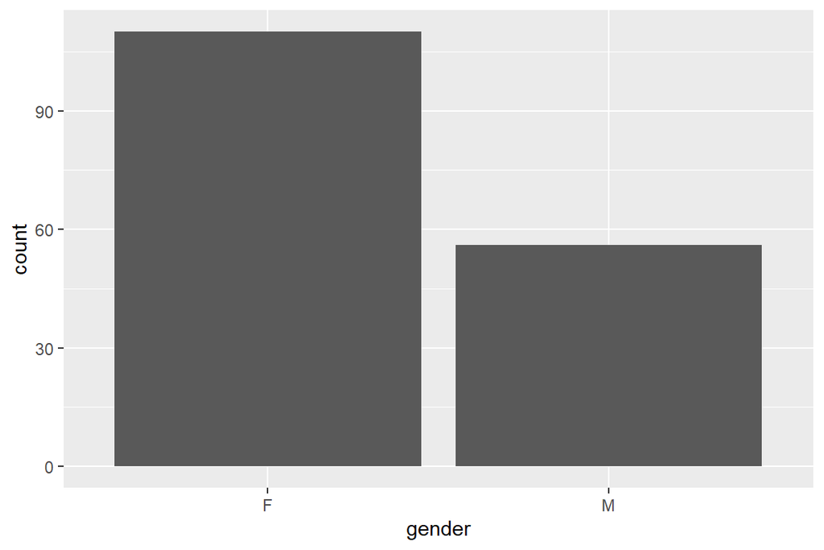

```r
learning2014 %>%
  ggplot(aes(x = gender)) +
  geom_bar()
```

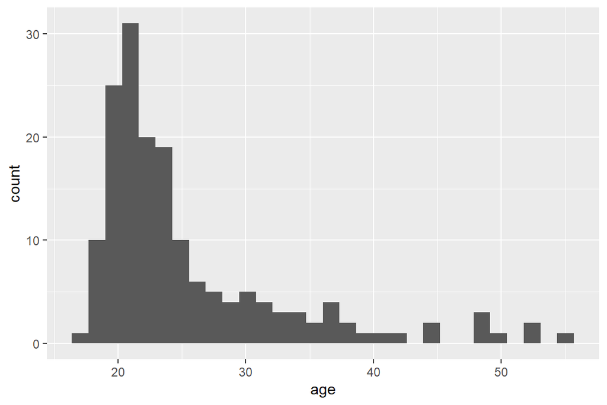

```r
learning2014 %>%
  ggplot(aes(x = age)) +
  geom_histogram()
```

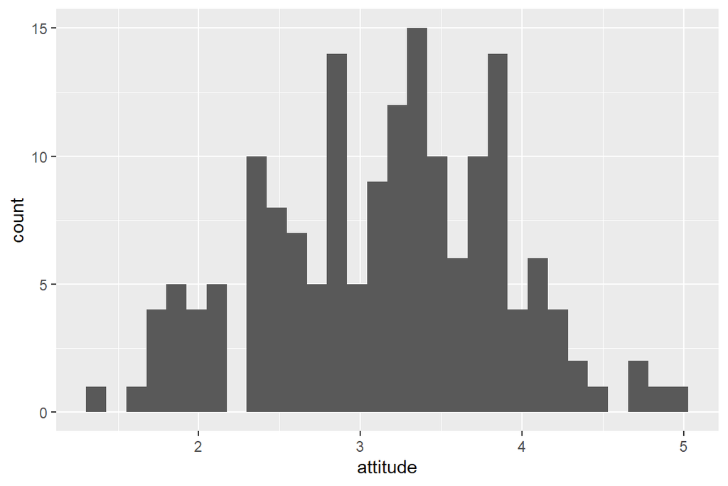

```r
learning2014 %>%
  ggplot(aes(x = attitude)) +
  geom_histogram()
```

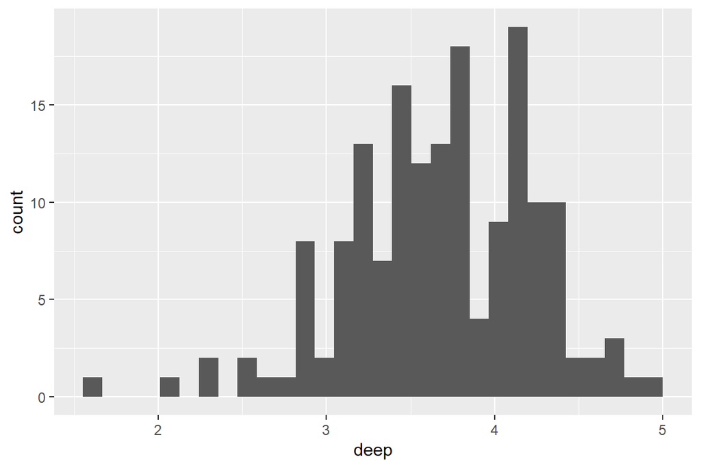

```r
learning2014 %>%
  ggplot(aes(x = deep)) +
  geom_histogram()
```

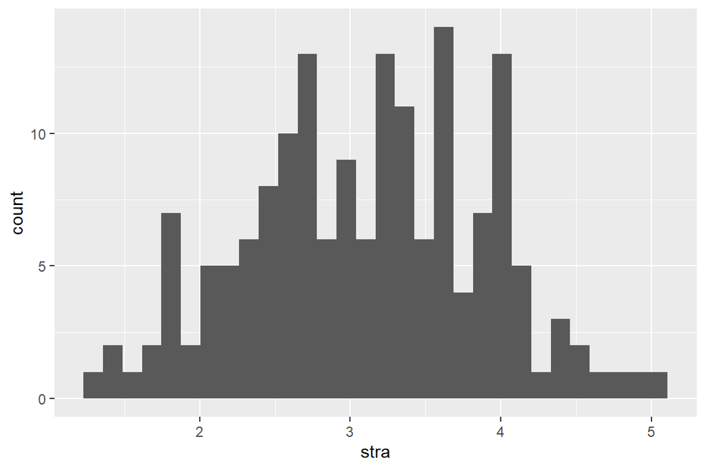

```r
learning2014 %>%
  ggplot(aes(x = stra)) +
  geom_histogram()
```

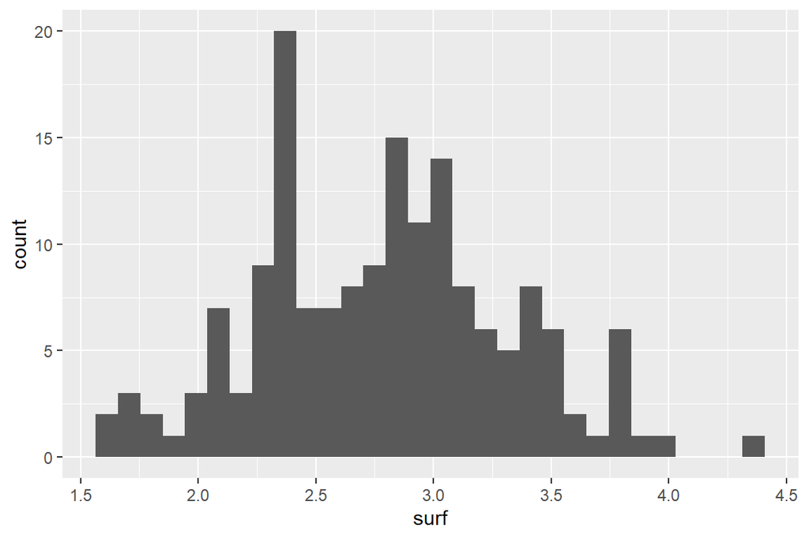

```r
learning2014 %>%
  ggplot(aes(x = surf)) +
  geom_histogram()
```

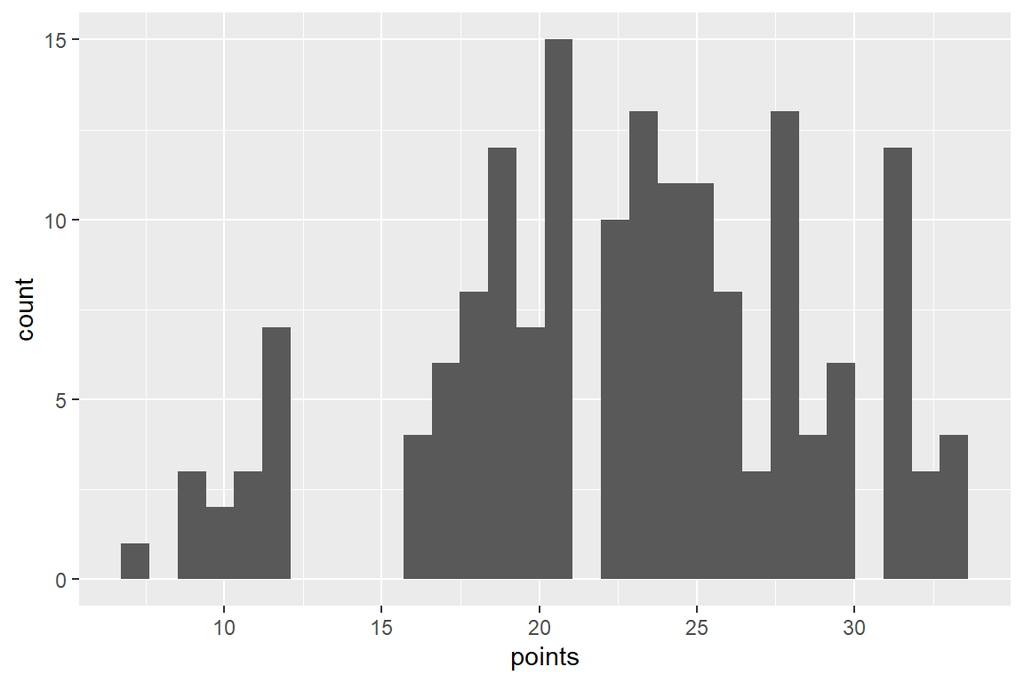

```r
learning2014 %>%
  ggplot(aes(x = points)) +
  geom_histogram()
```

Gender graph obviously shows that the number of female participants are almost twice the number of males. According to the age graph, majority of participants are 20-25 years old. The attitude graph seems to follow a normal distribution which indicate most of participant have a moderate attitude toward statistics. Comparing the mean of “deep” and the “surf”, it shows the students tend to learn the course material more deeply, instead of surface studying.

# 3. Fitting regression line

```r
# Regression model with three explantory variables
my_model_1 <- lm(points ~ attitude + stra + deep, data = learning2014)
summary(my_model_1)
```

```
##
## Call:
## lm(formula = points ~ attitude + stra + deep, data = learning2014)
##
## Residuals:
##      Min       1Q   Median       3Q      Max
## -17.5239  -3.4276   0.5474   3.8220  11.5112
##
## Coefficients:
##             Estimate Std. Error t value Pr(>|t|)
## (Intercept)  11.3915     3.4077   3.343  0.00103 **
## attitude      3.5254     0.5683   6.203 4.44e-09 ***
## stra          0.9621     0.5367   1.793  0.07489 .
## deep         -0.7492     0.7507  -0.998  0.31974
## ---
## Signif. codes:  0 '***' 0.001 '**' 0.01 '*' 0.05 '.' 0.1 ' ' 1
##
## Residual standard error: 5.289 on 162 degrees of freedom
## Multiple R-squared:  0.2097, Adjusted R-squared:  0.195
## F-statistic: 14.33 on 3 and 162 DF,  p-value: 2.521e-08
```

```r
# Excluding "deep" variable due to its insignificant relationship with  "points"
my_model_2 <- lm(points ~ attitude + stra, data = learning2014)
summary(my_model_2)
```

```
##
## Call:
## lm(formula = points ~ attitude + stra, data = learning2014)
##
## Residuals:
##      Min       1Q   Median       3Q      Max
## -17.6436  -3.3113   0.5575   3.7928  10.9295
##
## Coefficients:
##             Estimate Std. Error t value Pr(>|t|)
## (Intercept)   8.9729     2.3959   3.745  0.00025 ***
## attitude      3.4658     0.5652   6.132 6.31e-09 ***
## stra          0.9137     0.5345   1.709  0.08927 .
## ---
## Signif. codes:  0 '***' 0.001 '**' 0.01 '*' 0.05 '.' 0.1 ' ' 1
##
## Residual standard error: 5.289 on 163 degrees of freedom
## Multiple R-squared:  0.2048, Adjusted R-squared:  0.1951
## F-statistic: 20.99 on 2 and 163 DF,  p-value: 7.734e-09
```

```r
# Excluding "stra" variable as well
my_model_3 <- lm(points ~ attitude, data = learning2014)
summary(my_model_3)
```

```
##
## Call:
## lm(formula = points ~ attitude, data = learning2014)
##
## Residuals:
##      Min       1Q   Median       3Q      Max
## -16.9763  -3.2119   0.4339   4.1534  10.6645
##
## Coefficients:
##             Estimate Std. Error t value Pr(>|t|)
## (Intercept)  11.6372     1.8303   6.358 1.95e-09 ***
## attitude      3.5255     0.5674   6.214 4.12e-09 ***
## ---
## Signif. codes:  0 '***' 0.001 '**' 0.01 '*' 0.05 '.' 0.1 ' ' 1
##
## Residual standard error: 5.32 on 164 degrees of freedom
## Multiple R-squared:  0.1906, Adjusted R-squared:  0.1856
## F-statistic: 38.61 on 1 and 164 DF,  p-value: 4.119e-09
```

In the first model, we have used three explanatory variables of “attitude”, “stra”, and “deep”. According to the summary, there is no significant relationship between “deep” and “points”. Thus, we removed “deep” variable from the model, and fit the model again with “attitude” and “stra” as the explanatory variables; still, it seems “stra” has not statistically significant relationship with our target variable, “points”. So, we fit the model once again with only “attitude” as its explanatory variable. The summary shows a significant linear relationship between “attitude” and “points” which means those who have positive attitude toward statistics, get better points in this course.

# 4. Parameter interpretaion

Using the summary of fitted model, multiple R-squared in all three level, is low which indicates a weak relationship between our explanatory variables and points. However only one of these weak estimating relationship (between attitude and points) is significant.

# 5. diagnostic plots

```r
library(ggfortify)
```

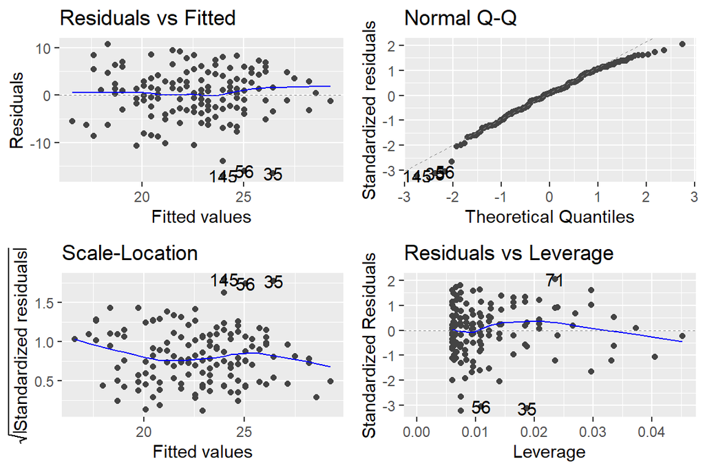

```r
autoplot(my_model_3)
```

The assumptions of linear regression are: - The relationship between the predictor (x) and the outcome (y) is assumed to be linear. - The residual errors are assumed to be normally distributed. - The residuals are assumed to have a constant variance (homoscedasticity) - residuals error terms are independent.

We have checked the above assumptions by diagnostic plots. Residual vs Fitted plot is without pattern that shows the relationship between variables (attitude and points) is linear. Normal Q-Q plot follows a straight line which shows residuals have normally distributed. From Residuals vs Leverage plot, we see there is only three influential/extreme values in the data (#71, #35, #56)

# Logistic Regression

```r
date()
```

```
## [1] "Tue Dec 13 03:10:00 2022"
```

## Task 2

```r
library(dplyr)

alc <- read.csv("data/alc.csv")
glimpse(alc)
```

```
## Rows: 370
## Columns: 35
## $ school     <chr> "GP", "GP", "GP", "GP", "GP", "GP", "GP", "GP", "GP", "GP",…
## $ sex        <chr> "F", "F", "F", "F", "F", "M", "M", "F", "M", "M", "F", "F",…
## $ age        <int> 18, 17, 15, 15, 16, 16, 16, 17, 15, 15, 15, 15, 15, 15, 15,…
## $ address    <chr> "U", "U", "U", "U", "U", "U", "U", "U", "U", "U", "U", "U",…
## $ famsize    <chr> "GT3", "GT3", "LE3", "GT3", "GT3", "LE3", "LE3", "GT3", "LE…
## $ Pstatus    <chr> "A", "T", "T", "T", "T", "T", "T", "A", "A", "T", "T", "T",…
## $ Medu       <int> 4, 1, 1, 4, 3, 4, 2, 4, 3, 3, 4, 2, 4, 4, 2, 4, 4, 3, 3, 4,…
## $ Fedu       <int> 4, 1, 1, 2, 3, 3, 2, 4, 2, 4, 4, 1, 4, 3, 2, 4, 4, 3, 2, 3,…
## $ Mjob       <chr> "at_home", "at_home", "at_home", "health", "other", "servic…
## $ Fjob       <chr> "teacher", "other", "other", "services", "other", "other", …
## $ reason     <chr> "course", "course", "other", "home", "home", "reputation", …
## $ guardian   <chr> "mother", "father", "mother", "mother", "father", "mother",…
## $ traveltime <int> 2, 1, 1, 1, 1, 1, 1, 2, 1, 1, 1, 3, 1, 2, 1, 1, 1, 3, 1, 1,…
```

[output cut: 22 more lines]

```r
colnames(alc)
```

```
##  [1] "school"     "sex"        "age"        "address"    "famsize"
##  [6] "Pstatus"    "Medu"       "Fedu"       "Mjob"       "Fjob"
## [11] "reason"     "guardian"   "traveltime" "studytime"  "schoolsup"
## [16] "famsup"     "activities" "nursery"    "higher"     "internet"
## [21] "romantic"   "famrel"     "freetime"   "goout"      "Dalc"
## [26] "Walc"       "health"     "failures"   "paid"       "absences"
## [31] "G1"         "G2"         "G3"         "alc_use"    "high_use"
```

the ‘alc’ data set contains 370 rows and 35 columns. We generated this data set through combining the two data sets from secondary school students in math class and portuguese language class regarding their study performance. We did this combination by removing the free columns which varied in two data sets, and keeping the common columns in two data sets. Now, our joined/combined data set have 35 variables.

## Task 3

dependent variable: high/low alcohol consumption (high_use) explanatory variables: school absences, age, family relationships (famrel), going out with friends (goout) hypothesis:

- school absences is more prevalent among students who consume more alcohol.
- Older students consume more alcohol compare to youngers.
- student who highly consume alcohol, have worse relationship with their family.
- student who highly consume alcohol, spent more time out with friends.

## Task 4

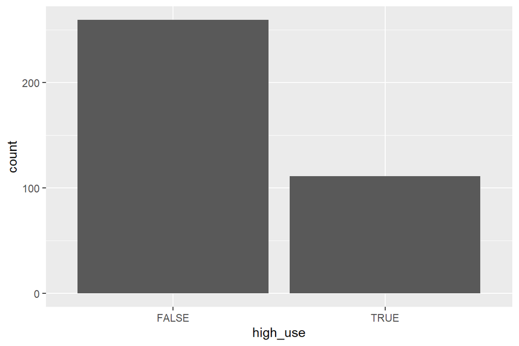

```r
library(ggplot2)

#  plot of high_use
g0 <- ggplot(alc, aes(x = high_use))
g0 + geom_bar()
```

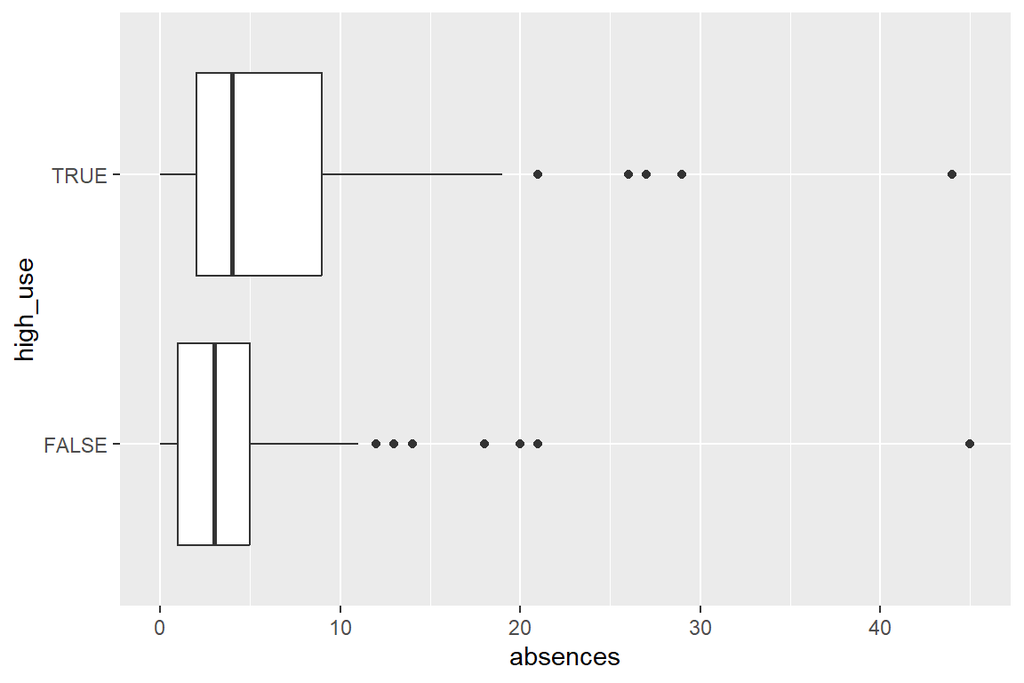

```r
#  plot of high_use and absences
g1 <- ggplot(alc, aes(x = absences, y = high_use ))
g1 + geom_boxplot()
```

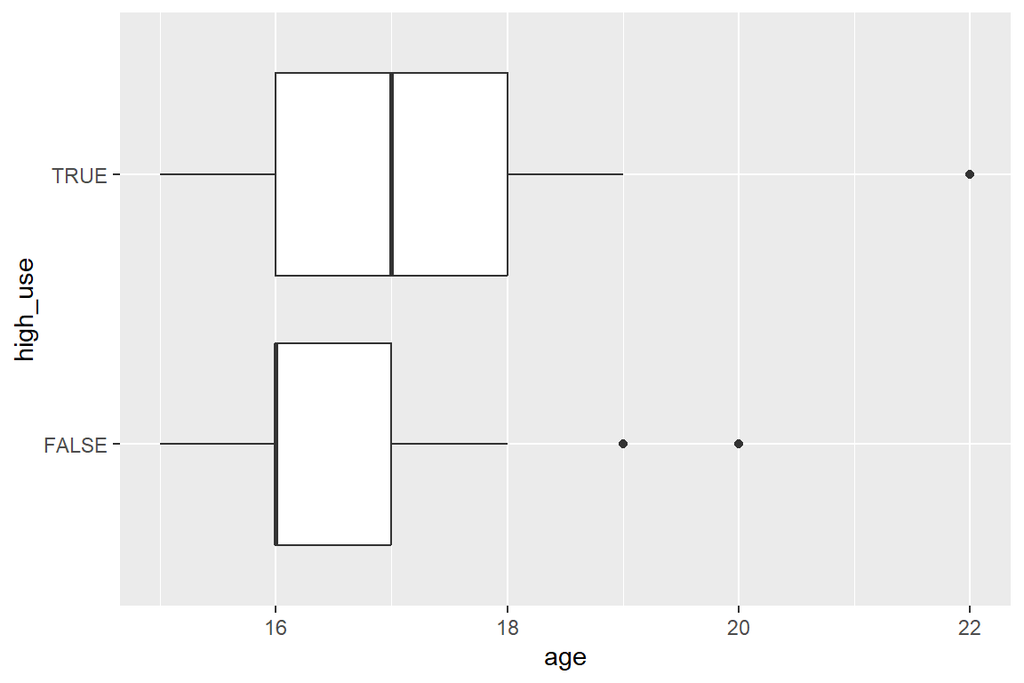

```r
#  plot of high_use and age
g2 <- ggplot(alc, aes(x = age, y = high_use ))
g2 + geom_boxplot()
```

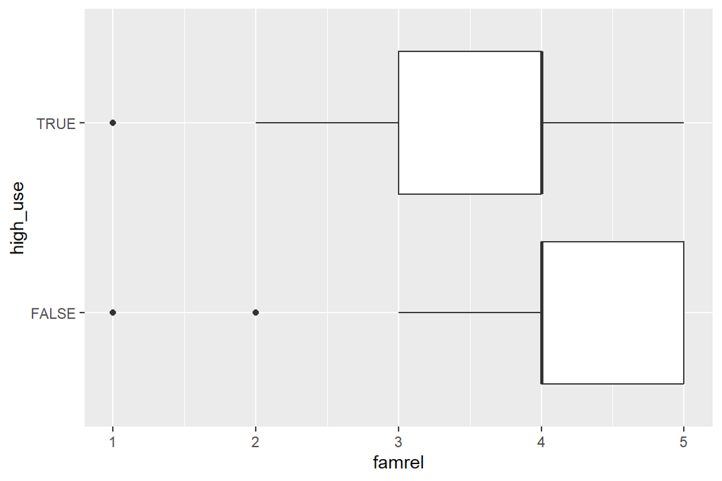

```r
#  plot of high_use and famrel
g3 <- ggplot(alc, aes(x = famrel, y = high_use ))
g3 + geom_boxplot()
```

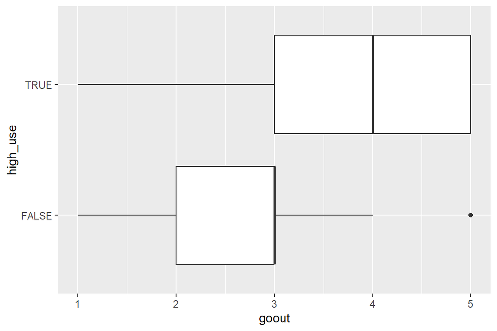

```r
#  plot of high_use and goout
g4 <- ggplot(alc, aes(x = goout, y = high_use ))
g4 + geom_boxplot()
```

```r
# table of high_use and absences
table(alc$high_use, alc$absences)
```

```
##
##          0  1  2  3  4  5  6  7  8  9 10 11 12 13 14 16 17 18 19 20 21 26 27 29
##   FALSE 50 37 40 31 24 16 16  9 14  5  5  2  3  1  1  0  0  1  0  2  1  0  0  0
##   TRUE  13 13 16  7 11  6  5  3  6  6  2  3  4  1  6  1  1  1  1  0  1  1  1  1
##
##         44 45
##   FALSE  0  1
##   TRUE   1  0
```

```r
# table of high_use and age
table(alc$high_use, alc$age)
```

```
##
##         15 16 17 18 19 20 22
##   FALSE 63 74 62 52  7  1  0
##   TRUE  18 28 35 25  4  0  1
```

```r
# table of high_use and famrel
table(alc$high_use, alc$famrel)
```

```
##
##           1   2   3   4   5
##   FALSE   6   9  39 128  77
##   TRUE    2   9  25  52  23
```

```r
# table of high_use and goout
table(alc$high_use, alc$goout)
```

```
##
##          1  2  3  4  5
##   FALSE 19 82 97 40 21
##   TRUE   3 15 23 38 32
```

## Task 5

```r
# logistic regression model with glm()
m <- glm(high_use ~ absences + age + famrel + goout, data = alc, family = "binomial")
summary(m)
```

```
##
## Call:
## glm(formula = high_use ~ absences + age + famrel + goout, family = "binomial",
##     data = alc)
##
## Deviance Residuals:
##     Min       1Q   Median       3Q      Max
## -1.8136  -0.7475  -0.5275   0.8913   2.3758
##
## Coefficients:
##             Estimate Std. Error z value Pr(>|z|)
## (Intercept) -3.60205    1.86854  -1.928  0.05389 .
## absences     0.07153    0.02197   3.256  0.00113 **
## age          0.08236    0.11082   0.743  0.45735
## famrel      -0.37837    0.13673  -2.767  0.00565 **
## goout        0.76162    0.12163   6.262  3.8e-10 ***
## ---
## Signif. codes:  0 '***' 0.001 '**' 0.01 '*' 0.05 '.' 0.1 ' ' 1
##
## (Dispersion parameter for binomial family taken to be 1)
##
##     Null deviance: 452.04  on 369  degrees of freedom
## Residual deviance: 382.24  on 365  degrees of freedom
## AIC: 392.24
##
## Number of Fisher Scoring iterations: 4
```

```r
# compute odds ratios (OR)
OR <- coef(m) %>% exp

# compute confidence intervals (CI)
confint(m)
```

```
##                   2.5 %      97.5 %
## (Intercept) -7.31749011  0.02902725
## absences     0.02958538  0.11702541
## age         -0.13475850  0.30092248
## famrel      -0.64963694 -0.11162801
## goout        0.52935037  1.00726865
```

```r
CI <- exp(confint(m))
CI
```

```
##                    2.5 %    97.5 %
## (Intercept) 0.0006638263 1.0294526
## absences    1.0300273714 1.1241480
## age         0.8739269431 1.3511046
## famrel      0.5222353453 0.8943769
## goout       1.6978289925 2.7381120
```

```r
# print out the odds ratios with their confidence intervals
cbind(OR, CI)
```

```
##                     OR        2.5 %    97.5 %
## (Intercept) 0.02726783 0.0006638263 1.0294526
## absences    1.07414506 1.0300273714 1.1241480
## age         1.08585016 0.8739269431 1.3511046
## famrel      0.68497820 0.5222353453 0.8943769
## goout       2.14174891 1.6978289925 2.7381120
```

According to the logistic regression model, we got more accurate outcomes regarding the relationship between our variables:

- There is a significant predictor relationship between school absences and high alcohol consumption. The odds ratio is 1.07 which is in the confidence interval (1.03 - 1.12). P-value is 0.001 that indicates the relationship is significant. So, our hypothesis is confirmed. Those who consumes more alcohol are more likely to be absent at school.
- Our model shows there is no significant relationship between age and alcohol consumption. Although the odds ratio is 1.08 which is in the confidence interval (0.87 - 1.35), P-value (which is 0.45) does not show significant relationship. Thus, our hypothesis is rejected.
- The third hypothesis is true. There is a significant negative relationship between alcohol consumption and family relationship. The odds ratio (0.68) is in the confidence interval (0.52 - 0.89) and P-value (0.005) is significant. Also, the estimate value is -0.37 which indicates negative relationship. It means those who consumes more alcohol probably have worse relationship with their families.
- The most significant is shown between high alcohol consumption and going out with friends. The odds ratio is 2.14 which is at the middle of the confidence interval (1.69-2.73). P-value is 3.8e-10 and estimate value is 0.76 show a strong significant relationship between alcohol consumption and ‘goout’ variable. Our model confirmed our hypothesis that those who consume more alcohol are more likely to spend more time outdoor.

## Task 6

```r
# Work with the exercise in this chunk, step-by-step. Fix the R code!
# alc is available

# fit the model
model <- glm(high_use ~ goout + famrel + absences, data = alc, family = "binomial")

# predict() the probability of high_use
probabilities <- predict(model, type = "response")

library(dplyr)
# add the predicted probabilities to 'alc'
alc <- mutate(alc, probability = probabilities)

# use the probabilities to make a prediction of high_use
alc <- mutate(alc, prediction = probability > 0.5)

# tabulate the target variable versus the predictions
table(high_use = alc$high_use, prediction = alc$prediction)
```

```
##         prediction
## high_use FALSE TRUE
##    FALSE   236   23
##    TRUE     67   44
```

```r
# Computing the total proportion of inaccurately classified individuals
loss_func <- function(class, prob) {
  n_wrong <- abs(class - prob) > 0.5
  mean(n_wrong)
}

inaccurately_classified <- loss_func(alc$high_use, alc$prediction)
inaccurately_classified
```

```
## [1] 0.2432432
```

## Task 7

```r
# K-fold cross-validation
library(boot)
cv <- cv.glm(data = alc, cost = loss_func, glmfit = model, K = 10)


# average number of wrong predictions in the cross validation
cv$delta[1]
```

```
## [1] 0.2513514
```

The test set performance in our model is 0.25, which is a slightly higher than the test set performance in the Exercise3 which was 0.24.

# Clustering and Classification

## Analysis Exercises

```r
date()
```

```
## [1] "Tue Dec 13 03:10:01 2022"
```

## Exercise 2

```r
library(MASS)
# load the data
data("Boston")

# explore the data set
str(Boston)
```

```
## 'data.frame':    506 obs. of  14 variables:
##  $ crim   : num  0.00632 0.02731 0.02729 0.03237 0.06905 ...
##  $ zn     : num  18 0 0 0 0 0 12.5 12.5 12.5 12.5 ...
##  $ indus  : num  2.31 7.07 7.07 2.18 2.18 2.18 7.87 7.87 7.87 7.87 ...
##  $ chas   : int  0 0 0 0 0 0 0 0 0 0 ...
##  $ nox    : num  0.538 0.469 0.469 0.458 0.458 0.458 0.524 0.524 0.524 0.524 ...
##  $ rm     : num  6.58 6.42 7.18 7 7.15 ...
##  $ age    : num  65.2 78.9 61.1 45.8 54.2 58.7 66.6 96.1 100 85.9 ...
##  $ dis    : num  4.09 4.97 4.97 6.06 6.06 ...
##  $ rad    : int  1 2 2 3 3 3 5 5 5 5 ...
##  $ tax    : num  296 242 242 222 222 222 311 311 311 311 ...
##  $ ptratio: num  15.3 17.8 17.8 18.7 18.7 18.7 15.2 15.2 15.2 15.2 ...
##  $ black  : num  397 397 393 395 397 ...
##  $ lstat  : num  4.98 9.14 4.03 2.94 5.33 ...
##  $ medv   : num  24 21.6 34.7 33.4 36.2 28.7 22.9 27.1 16.5 18.9 ...
```

```r
summary(Boston)
```

```
##       crim                zn             indus            chas
##  Min.   : 0.00632   Min.   :  0.00   Min.   : 0.46   Min.   :0.00000
##  1st Qu.: 0.08205   1st Qu.:  0.00   1st Qu.: 5.19   1st Qu.:0.00000
##  Median : 0.25651   Median :  0.00   Median : 9.69   Median :0.00000
##  Mean   : 3.61352   Mean   : 11.36   Mean   :11.14   Mean   :0.06917
##  3rd Qu.: 3.67708   3rd Qu.: 12.50   3rd Qu.:18.10   3rd Qu.:0.00000
##  Max.   :88.97620   Max.   :100.00   Max.   :27.74   Max.   :1.00000
##       nox               rm             age              dis
##  Min.   :0.3850   Min.   :3.561   Min.   :  2.90   Min.   : 1.130
##  1st Qu.:0.4490   1st Qu.:5.886   1st Qu.: 45.02   1st Qu.: 2.100
##  Median :0.5380   Median :6.208   Median : 77.50   Median : 3.207
##  Mean   :0.5547   Mean   :6.285   Mean   : 68.57   Mean   : 3.795
##  3rd Qu.:0.6240   3rd Qu.:6.623   3rd Qu.: 94.08   3rd Qu.: 5.188
##  Max.   :0.8710   Max.   :8.780   Max.   :100.00   Max.   :12.127
##       rad              tax           ptratio          black
##  Min.   : 1.000   Min.   :187.0   Min.   :12.60   Min.   :  0.32
##  1st Qu.: 4.000   1st Qu.:279.0   1st Qu.:17.40   1st Qu.:375.38
##  Median : 5.000   Median :330.0   Median :19.05   Median :391.44
##  Mean   : 9.549   Mean   :408.2   Mean   :18.46   Mean   :356.67
##  3rd Qu.:24.000   3rd Qu.:666.0   3rd Qu.:20.20   3rd Qu.:396.23
##  Max.   :24.000   Max.   :711.0   Max.   :22.00   Max.   :396.90
##      lstat            medv
##  Min.   : 1.73   Min.   : 5.00
##  1st Qu.: 6.95   1st Qu.:17.02
##  Median :11.36   Median :21.20
##  Mean   :12.65   Mean   :22.53
##  3rd Qu.:16.95   3rd Qu.:25.00
##  Max.   :37.97   Max.   :50.00
```

Description of the data set:

Boston data set, is a collection of data regarding housing values in suburbs of Boston. It checks 14 items on 506 housings, which means we have 14 variables and 506 observations in the data set. (14 columns and 506 rows) All variables are numerical including 2 integers and 12 floating-points.